# HW1B

```r
# Question 6
#logistic regression
logreg <- glm(sdat$UseSocialMedia ~ sdat$Voted_Trump + sdat$Income + sdat$Educ_Years + sdat$Age, data = sdat, family = 'binomial')
summary(logreg)
```

```
##
## Call:
## glm(formula = sdat$UseSocialMedia ~ sdat$Voted_Trump + sdat$Income +
##     sdat$Educ_Years + sdat$Age, family = "binomial", data = sdat)
##
## Deviance Residuals:
##     Min       1Q   Median       3Q      Max
## -2.6613   0.2718   0.3670   0.5413   0.9611
##
## Coefficients:
##                    Estimate Std. Error z value Pr(>|z|)
## (Intercept)       3.2103555  0.1542173  20.817  < 2e-16 ***
## sdat$Voted_Trump  0.0650329  0.0523702   1.242  0.21431
## sdat$Income      -0.0011394  0.0004147  -2.747  0.00601 **
## sdat$Educ_Years   0.0934386  0.0101634   9.194  < 2e-16 ***
## sdat$Age         -0.0494959  0.0015225 -32.510  < 2e-16 ***
## ---
## Signif. codes:  0 '***' 0.001 '**' 0.01 '*' 0.05 '.' 0.1 ' ' 1
##
## (Dispersion parameter for binomial family taken to be 1)
##
##     Null deviance: 13300  on 18119  degrees of freedom
## Residual deviance: 12011  on 18115  degrees of freedom
## AIC: 12021
##
## Number of Fisher Scoring iterations: 5
```

My result saw that C.P. an individual is 6.5% point more likely to use social media when they voted for trump compared those who did not even when accounting for income, education years, and age.But we do see that the variable is statically insignificant at 95% confidence interval. Other variable such as the education years and age was more statically significant to ether or not an individual used social media.

```r
# B
logreg$deviance / logreg$null.deviance
```

```
## [1] 0.9030694
```

```r
# C
(exp(coef(logreg)["sdat$Voted_Trump"])-1)*100
```

```
## sdat$Voted_Trump
##         6.719416
```

```r
(coef(logreg)["sdat$Voted_Trump"])*100
```

```
## sdat$Voted_Trump
##         6.503293
```

The odds of social media use for being Trump voter is 6.719416% point

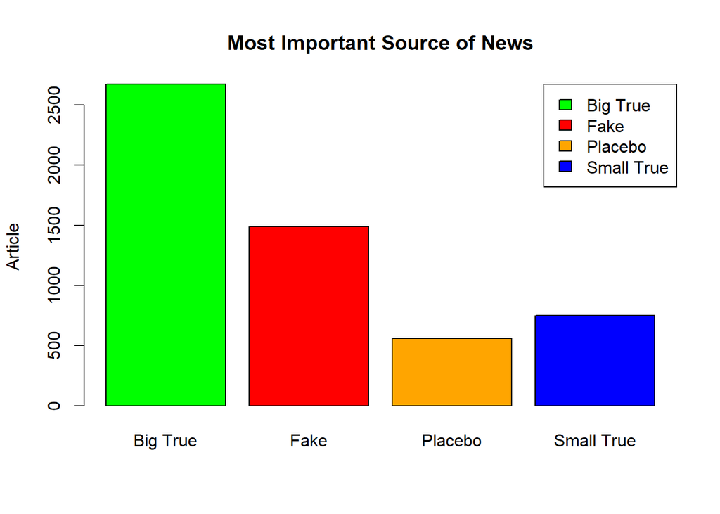

```r
# Question 7
df <- sdat[sdat$Heard == "Yes",]
source <- tapply(rep(1, nrow(df)), df$BarLabel, sum)
source2 <- tapply(rep(1, nrow(df)), df[,c("ThoughtTrue", "BarLabel")], sum)
thoughtcol <- c("red", "yellow", "green")
labelcol <- c("green", "red", "orange", "blue")
barplot(source, main = "Most Important Source of News", ylab = "Article", col =  labelcol)
legend("topright", c("Big True", "Fake", "Placebo", "Small True"), fill= labelcol)
```

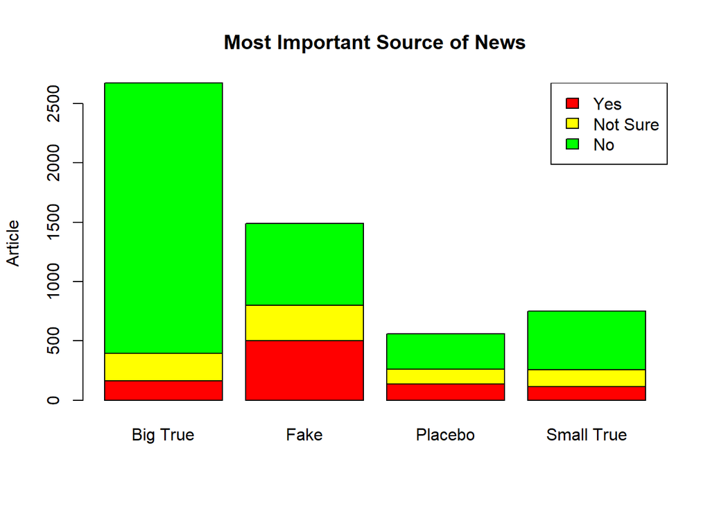

```r
barplot(source2, main = "Most Important Source of News", ylab = "Article", col =  thoughtcol)
legend("topright", c("Yes", "Not Sure", "No"), fill= thoughtcol)
```

```r
# Question 8
# A
pf <- sdat[sdat$BarLabel == "Fake" | sdat$BarLabel == "Placebo",]
pf$BarLabelbi <- ifelse(pf$BarLabel == "Fake", 1, 0)
pf$Heardbi <- ifelse(pf$Heard == "Yes", 1, 0)
```

Setting up for the regression

```r
# B
reg <-  glm(pf$BarLabelbi ~ pf$Heardbi, data =  pf)
summary(reg)
```

```
##
## Call:
## glm(formula = pf$BarLabelbi ~ pf$Heardbi, data = pf)
##
## Deviance Residuals:
##     Min       1Q   Median       3Q      Max
## -0.7273  -0.6944   0.3056   0.3056   0.3056
##
## Coefficients:
##             Estimate Std. Error t value Pr(>|t|)
## (Intercept) 0.694439   0.004574 151.839  < 2e-16 ***
## pf$Heardbi  0.032834   0.011113   2.955  0.00314 **
## ---
## Signif. codes:  0 '***' 0.001 '**' 0.01 '*' 0.05 '.' 0.1 ' ' 1
##
## (Dispersion parameter for gaussian family taken to be 0.2098831)
##
##     Null deviance: 2536.8  on 12079  degrees of freedom
## Residual deviance: 2535.0  on 12078  degrees of freedom
## AIC: 15426
##
## Number of Fisher Scoring iterations: 2
```

my finding saw that C.P. when an individual heard about an article they were 3.2834% point more likely the article to be false compared to hearing a placebo.

```r
# Question 9
# A
K <- ifelse(sdat$BarLabel != "Fake" | sdat$BarLabel != "Placebo" & sdat$ThoughtTrue == "Yes", 1, ifelse(sdat$ThoughtTrue == "Not sure", 0.5, 0))
# B
Party <- ifelse(sdat$Democrat == 1, 1, 0)
```

making our variable

```r
# C
reg <- glm(K~Party, data = sdat)
summary(reg)
```

```
##
## Call:
## glm(formula = K ~ Party, data = sdat)
##
## Deviance Residuals:
##     Min       1Q   Median       3Q      Max
## -0.7075  -0.2075   0.2981   0.3150   0.3263
##
## Coefficients:
##             Estimate Std. Error t value Pr(>|t|)
## (Intercept) 0.668057   0.006152 108.589  < 2e-16 ***
## Party       0.005639   0.001455   3.875 0.000107 ***
## ---
## Signif. codes:  0 '***' 0.001 '**' 0.01 '*' 0.05 '.' 0.1 ' ' 1
##
## (Dispersion parameter for gaussian family taken to be 0.1764569)
##
##     Null deviance: 3199.7  on 18119  degrees of freedom
## Residual deviance: 3197.0  on 18118  degrees of freedom
## AIC: 19994
##
## Number of Fisher Scoring iterations: 2
```

In our regression we saw that when a individual is Democrat they are 0.5639% point more likely to correctly identifies whether the article is true or false

```r
# D
reg <- glm(K~Party + sdat$Income + sdat$Educ_Years + sdat$Age, data = sdat)
summary(reg)
```

```
##
## Call:
## glm(formula = K ~ Party + sdat$Income + sdat$Educ_Years + sdat$Age,
##     data = sdat)
##
## Deviance Residuals:
##     Min       1Q   Median       3Q      Max
## -0.7572  -0.2353   0.2783   0.3162   0.4131
##
## Coefficients:
##                   Estimate Std. Error t value Pr(>|t|)
## (Intercept)      0.8266254  0.0209137  39.526  < 2e-16 ***
## Party            0.0049309  0.0014677   3.360 0.000782 ***
## sdat$Income     -0.0002245  0.0000577  -3.891 0.000100 ***
## sdat$Educ_Years -0.0067902  0.0013353  -5.085 3.71e-07 ***
## sdat$Age        -0.0008386  0.0001844  -4.548 5.45e-06 ***
## ---
## Signif. codes:  0 '***' 0.001 '**' 0.01 '*' 0.05 '.' 0.1 ' ' 1
##
## (Dispersion parameter for gaussian family taken to be 0.1754196)
##
##     Null deviance: 3199.7  on 18119  degrees of freedom
## Residual deviance: 3177.7  on 18115  degrees of freedom
## AIC: 19890
##
## Number of Fisher Scoring iterations: 2
```

We controlled for Income, education years, and age, we chose these controls because these factor tend to split voters into either party, younger people tend to be democrats, higher income tend to be republican and educ also contributed towards the split. With the control there was evens smaller % point at 0.49309% point with 0.07081 less likely to be correct.

```r
# Question 10
# A
B <- ifelse(sdat$ThoughtTrue == "Yes", 1, ifelse(sdat$ThoughtTrue == "Not sure", 0.5, 0))
```

setting var

```r
# B
reg <- glm(B~Party, data = sdat)
summary(reg)
```

```
##
## Call:
## glm(formula = B ~ Party, data = sdat)
##
## Deviance Residuals:
##      Min        1Q    Median        3Q       Max
## -0.48013  -0.43352   0.04784   0.51987   0.57581
##
## Coefficients:
##             Estimate Std. Error t value Pr(>|t|)
## (Intercept) 0.414871   0.006040  68.689  < 2e-16 ***
## Party       0.009322   0.001428   6.526 6.93e-11 ***
## ---
## Signif. codes:  0 '***' 0.001 '**' 0.01 '*' 0.05 '.' 0.1 ' ' 1
##
## (Dispersion parameter for gaussian family taken to be 0.1700702)
##
##     Null deviance: 3088.6  on 18119  degrees of freedom
## Residual deviance: 3081.3  on 18118  degrees of freedom
## AIC: 19326
##
## Number of Fisher Scoring iterations: 2
```

We found that if individual is Democrat they are 0.9322% point more likely to believe that an article is true then a Republican.

```r
# C
regint <- glm(B~Party + sdat$Democrat*sdat$ArticleProClinton + sdat$Republican*sdat$ArticleProTrump, data = sdat)
summary(regint)
```

```
##
## Call:
## glm(formula = B ~ Party + sdat$Democrat * sdat$ArticleProClinton +
##     sdat$Republican * sdat$ArticleProTrump, data = sdat)
##
## Deviance Residuals:
##      Min        1Q    Median        3Q       Max
## -0.55668  -0.39684   0.01068   0.45889   0.67249
##
## Coefficients: (1 not defined because of singularities)
##                                       Estimate Std. Error t value Pr(>|t|)
## (Intercept)                           0.381650   0.020613  18.515  < 2e-16 ***
## Party                                 0.015577   0.004988   3.123  0.00179 **
## sdat$Democrat                        -0.069722   0.016433  -4.243 2.22e-05 ***
## sdat$ArticleProClinton                0.029779   0.009500   3.135  0.00172 **
## sdat$Republican                      -0.123630   0.017581  -7.032 2.11e-12 ***
## sdat$ArticleProTrump                        NA         NA      NA       NA
## sdat$Democrat:sdat$ArticleProClinton  0.153411   0.013923  11.019  < 2e-16 ***
## sdat$Republican:sdat$ArticleProTrump  0.189621   0.015520  12.218  < 2e-16 ***
## ---
## Signif. codes:  0 '***' 0.001 '**' 0.01 '*' 0.05 '.' 0.1 ' ' 1
##
## (Dispersion parameter for gaussian family taken to be 0.1654809)
##
##     Null deviance: 3088.6  on 18119  degrees of freedom
## Residual deviance: 2997.4  on 18113  degrees of freedom
## AIC: 18835
##
## Number of Fisher Scoring iterations: 2
```